# Introduktion till Python

I den här laborationen introducerar vi grundläggande Python och visar på några några skillnader mot R. Laborationen är tänkt att ge er en introduktion till ett mer datavetenskapligt programmeringsspråk som också är mycket användbart för statistik och data science.

## Komma igång

Ni kan välja flera olika sätt att köra Python. Har ni redan ett sätt som ni föredrar går det bra, men förslagsvis så skriver ni er kod i notebook-format. Nedan är tre förslag på sätt att skriva er kod.

**1. Google Colab**

Google Colab är ett enkelt sätt att komma igång med Python i ett notebook format och kräver ingen installation men kräver ett Google-konto(?).

**2. RStudio**

```r
install.packages("reticulate")
```

Ni kan sen öppna en ny fil och välja “Python script” för att köra Python, direkt i RStudio.

**3. Visual Studio eller annan editor**

## Stil

R kod följer allt för sällan en enhetlig stil. Python har en [stilguide](https://peps.python.org/pep-0008/) som ni inte behöver läsa, men som är nyttig om ni vill skriva mer Python-kod. Stil kan variera, och om ni skriver kod i ett sammanhang som redan har en stil så bör ni följa den. Nedan listas några enkla regler att följa som är vanligt förekommande i flera programmeringsspråk. Ni förväntas följa dem i den här labben.

- Variabel- och funktionsnamn följer `lower_case_with_underscore`
- Klassnamn följer `CapWords`
- 4 mellanslags indenteringsavstånd

## Uppgift 1 - grunder och syntax

Syntax inom programmering är de regler och strukturer som måste följas när du skriver kod för att programmet ska förstås och fungera korrekt. Syntaxen skiljer sig generellt mellan olika programmeringsspråk, även om det finns generella mönster som förekommer i alla språk så som tilldelning (<-), loopar, och if/else-satser. Pythons syntax är framtaget för att vara främja läsbarheten i koden och ger en möjlighet att skriva väldigt läsbar kod. Utöver syntax så skiljer sig R och Python åt på flera sätt, R är inriktat mot statistik och Python är mer generellt, ett så kallat “general purpose programming language”. Python är skrivet mer datavetenskapligt, och innehåller bland annat fler explicita datastrukturer och möjligheten till at skriva objektorienterad kod. I den här uppgiften ska ni skriva om kod från R kod till Python kod givet de skillnader i syntax som beskrivs och enligt de möjligheter som Python erbjuder.

Ni kan lösa följande uppgifter antingen genom att skriva koden i Google Colab, använd i så fall en cell till en uppgift, eller i RStudio med hjälp av `reticulate`, eller i någon annan IDE, så länge ni kan visa upp, förklara, och köra koden. Väljer ni att lösa uppgiften i RStudio kan ni använda det här dokumentet och skriva in era lösningar, se exempel i första uppgiften.

**Notera:** Output kan skilja sig mellan R och Python. Ni ska skriva kod som har samma funktion i båda språken, inte nödvändigtvis identisk output. T.ex. så skiljer sig output från en lista i R mot en “dictionary” i Python.

### (a) Tilldelning

I R används `<-` för att tilldela variabler värden medan Python istället använder `=`. Skriv om följande kod till Python kod och se till att den går att köra.

**R**

```r
# Assigning a value to a variable
x <- 10
y <- "hello"
```

**Python**

```python
# Write your solution here
```

### (b) Datastrukturer och indexering

En datastruktur är ett objekt som strukturerar data och möjliggör sökning, kategorisering, och lagring av information. I R används primärt två datastrukturer, vektorer och listor. I Python finns inga vektorer, bara listor, men också fler datatyper som “tuples” och “dictionaries”. Använd internet, LLMs, eller [den här dokumentationen](https://docs.python.org/3/tutorial/datastructures.html#) för att läsa mer om listor, tuples, och dictionaries i Python. Gör sedan följande uppgifter:

1. Skriv sedan om den här koden till Python kod med rätt datatyper (datastrukturer).
2. Redogör för skillnaden mellan en lista och en tuple.

Tips: För att se en värdet av en variabel i Python, använd funktionen `print` (om ni använder notebooks så kan ni skriva ut variabeln, precis som i R).

**R**

```r
# Vector
v <- c(1, 2, 3)
v
```

```
[1] 1 2 3
```

```r
# List
l <- list("Apple", "Orange", "Pear")
l
```

```
[[1]]
[1] "Apple"

[[2]]
[1] "Orange"

[[3]]
[1] "Pear"
```

```r
# Dictionary
d <- list(apple = "crunchy", orange = "juicy", pear = "sweet")
d
```

```
$apple
[1] "crunchy"

$orange
[1] "juicy"

$pear
[1] "sweet"
```

### (c) Loopar och if/else-satser

Python använder inte “måsvingar” som i R, istället används indentering för att bestämma vilken kod som exekveras inom en loop eller en if-sats. Indentering är antalet mellanrum innan koden skrivs. Det är alltid snyggt att indentera innehåll i loopar eller if-satser, men i Python är det en del av syntaxen. Likt R så fungerar for-looparna som “foreach”-loopar, där det man “loopar” över är innehållet i en datastruktur, till exempel en vektor eller lista. Läs på internet, använd LLMs, eller kolla på [den här dokumentationen](https://docs.python.org/3/tutorial/controlflow.html#if-statements) för att se exempel och lära er mer om for-loopar och if-satser. Skriv om den följande R-koden till Python-kod.

**R**

```r
numbers <- seq(1, 10)
for (number in numbers) {
    print(number)
    if (number == 5) print("Five")
}
```

```
[1] 1
[1] 2
[1] 3
[1] 4
[1] 5
[1] "Five"
[1] 6
[1] 7
[1] 8
[1] 9
[1] 10
```

### (d) Funktioner

För att definera en funktion i R använder vi `function`, men i Python använder man istället `def` och sedan funktionsnamnet. Läs den här [dokumentationen](https://docs.python.org/3/tutorial/controlflow.html#defining-functions) och översätt följande kod.

**R**

```r
multiply <- function(x, y) {
    return(x * y)
}
multiply(2, 22)
```

```
[1] 44
```

### (e) Paket

R är gjort specifikt för statistik. Det gör R till ett mycket användbart språk för att göra just statistisk analys, även om man allt som oftast vill använda fler paket för att skriva kraftfullare kod (jag kan rekommendera `tidyverse` för dataanalys). Python är ett “general purpose programming language” och inte byggt för ett specifikt ändamål. Därför är Python väldigt begränsat utan att importera paket och för att göra statistisk analys så behöver vi ett antal paket. [`numpy`](https://numpy.org/) används för matematiska beräkningar och är ett väldigt vanligt paket, [`pandas`](https://pandas.pydata.org/) är populärt för att jobba med tabelldata, motsvarande `data.frames` i R, och [`matplotlib`](https://matplotlib.org/) är nog det vanligaste paketet för att visualisera data. Ni behöver inte läsa på om pakete, men ni ska använda dem (och inga andra) för att skriva om den följande koden från R till Python. Beräkna medelvärdet både genom att använda `numpy` och `pandas`.

**Tips**

För att importera paketen och ladda datamaterialet i Python så kan ni använda följande kod:

```python
import numpy as np
import pandas as pd
import matplotlib.pyplot as plt

df = pd.read_csv("https://raw.githubusercontent.com/fileds/umu_stat_b_python/main/penguins.csv")
```

Kan ni inte ladda paketen (ej Google Colab), se till att de är installerade. Annars kan ni installera dem så här

- **Windows**: Öppna “Command Prompt” och skriv in följande kommando `py -m pip install --upgrade pip numpy pandas matplotlib`
- **Mac**: Öppna “Terminal” och skriv in följande kommando `python3 -m pip install --upgrade pip numpy pandas matplotlib`

Om ni kör Python i **RStudio** så behöver ni installera Python-paketen genom följande kod:

```r
reticulate::py_install("numpy")
reticulate::py_install("matplotlib")
reticulate::py_install("pandas")
```

**R**

```r
penguins <- read.csv("penguins.csv")
# Print head of data frame
head(penguins)
```

```
  species    island bill_length_mm bill_depth_mm flipper_length_mm body_mass_g
1  Adelie Torgersen           39.1          18.7               181        3750
2  Adelie Torgersen           39.5          17.4               186        3800
3  Adelie Torgersen           40.3          18.0               195        3250
4  Adelie Torgersen             NA            NA                NA          NA
5  Adelie Torgersen           36.7          19.3               193        3450
6  Adelie Torgersen           39.3          20.6               190        3650
     sex year
1   male 2007
2 female 2007
3 female 2007
4   <NA> 2007
5 female 2007
6   male 2007
```

```r
# Print head of species column
head(penguins$species)
```

```
[1] "Adelie" "Adelie" "Adelie" "Adelie" "Adelie" "Adelie"
```

```r
# Compute mean of flipper_length_mm
mean(penguins$flipper_length_mm, na.rm = TRUE)
```

```
[1] 200.9152
```

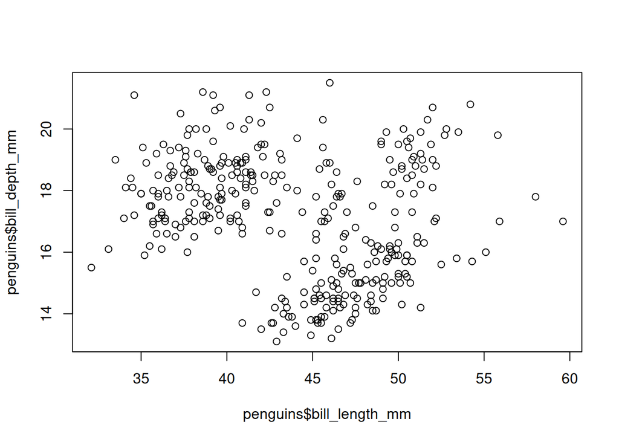

```r
# Plot bill_length_mm vs bill_depth_mm
plot(penguins$bill_length_mm, penguins$bill_depth_mm)
```

### (f) Objektorienterad programmering

R är ett “functional programming languange” som lämpar sig för att använda funktioner på funktioner, därav “pipe”-operatorn. Python tillåter “functional programming” men mycket Python-kod är skrivet som “Object Oriented Programming (OOP)” eller objektorienterad programmering på svenska. Tanken med objektorienterad programmering är att jobba så mycket som möjligt med objekt som har inbyggda variabler, ibland kallade fält, och funktioner, ibland kallade metoder. Ett annat kraftullt koncept inom objektorienterad programmering är arv: möjligheten för klasser att ärva från en superklass. Ni kan läsa mer om klasser [här](https://docs.python.org/3/tutorial/classes.html). “Functional programmin” är väldigt användbart för just statistik och data science, men OOP har stora fördelar i andra tillämpningar. I den här uppgiften är tanken att ni ska få en idé om fördelarna med OOP i en helt annan tillämpning än statistik/data science.

I den här uppgiften ska ni skriva objektorienterad kod. Er kod ska

1. Definera en superklass `Customer` med fälten `name` och `email` och med den oimplementerade metoden `send_newsletter` (se exempel med `n_wheels` nedan).
2. Definera två subklasser, `RegularCustomer` och `PremiumCustomer`, som implementerar `send_newsletter` genom att skriva ut (`print`) följande strängar:
   - `RegularCustomer`: `[mailto:<email>]Dear <name>, check out our weekly deals!` och för
   - `PremiumCustomer`: `[mailto:<email>]Dear <name>, enjoy exclusive premium offers and discounts!`.
3. Skapa en `RegularCustomer`, Alex, och en `PremiumCustomer`, Jordan, och spara dem i en lista, `customers`.
4. Skicka ut nyhetsbrev (skriva ut) till alla kunder i listan `customers` i en for-loop.

Utgå från Python exemplet för att skriva er kod, och R exemplet längre ned för att se hur utskrifterna ska se ut. Observera skillnaden i *koden*, R är inte ett objektorienterat språk utan använder istället funktioner.

**Exempel Python**

I det här exemplet ser vi hur subklassen `Bike` skapas genom att ärva superklassen `Vehicle` och implementera funktionen `n_wheels` som returnerar antalet hjul fordonet har. För att komma åt fält och metoder inom en *instans* av en klass, dvs. en realisation av klassen, använder vi punkt, `.`. Notera att `.` är reserverat för det här ändamålet i Python, och ni kan därmed inte använda det i variabelnamn.

```python
# Define super class Vehicle
class Vehicle:
    def __init__(self, name):
        self.name = name

    # Define function returning the number of wheels of the vehicle
    def n_wheels(self):
        raise NotImplementedError("Subclass must implement this method")

# Defining Bike class, inheriting from Vehicle
class Bike(Vehicle):
    def n_wheels(self):
        return 2

bike = Bike("Crescent")
# Using the dot, ., to access class fields
bike.name
```

```
'Crescent'
```

```python
# Using the dot, ., to access class method
bike.n_wheels()
```

```
2
```

**Exempel R**

Den här koden åstadkommer det ni ska göra i Python, men i R. R är ett “functional programming language” och har stöder inte OOP naturligt, istället måste funktioner användas. Observera att ni ska utgå från Python-koden ovan och ni behöver inte förstå R koden i sin helhet, bara observera utskrifterna längst ned.

```r
# Define the Customer 'class'
Customer <- function(name, email) {
    list(
      name = name,
      email = email,
      send_newsletter = function() {
        stop("send_newsletter() needs to be defined in the subclass.")
      }
    )
}

# Define the RegularCustomer 'subclass'
RegularCustomer <- function(name, email) {
    customer <- Customer(name, email)
    customer$send_newsletter <- function() {
      cat(sprintf("[mailto:%s]Dear %s, check out our weekly deals!\n", customer$email, customer$name))
    }
    customer
}

# Define the PremiumCustomer 'subclass'
PremiumCustomer <- function(name, email) {
    customer <- Customer(name, email)
    customer$send_newsletter <- function() {
      cat(sprintf("[mailto:%s]Dear %s, enjoy exclusive premium offers and discounts!\n", customer$email, customer$name))
    }
    customer
}

# Example usage
customers <- list(
    RegularCustomer("Alex", "alex@example.com"),
    PremiumCustomer("Jordan", "jordan@example.com")
)

for (customer in customers) {
    customer$send_newsletter()
}
```

```
[mailto:alex@example.com]Dear Alex, check out our weekly deals!
[mailto:jordan@example.com]Dear Jordan, enjoy exclusive premium offers and discounts!
```

## Uppgift 2 - Centrala gränsvärdessatsen

**R**

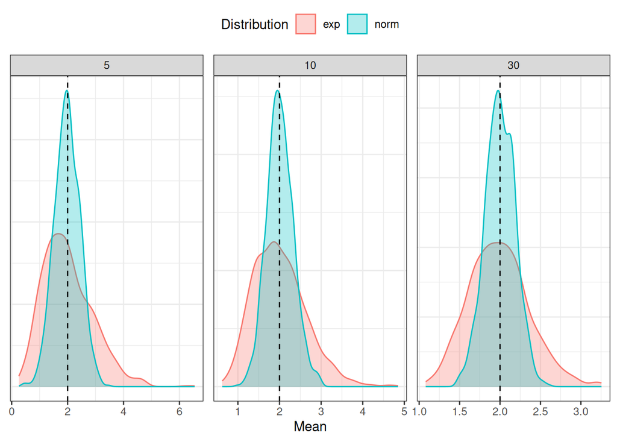

```r
library(tidyverse)
set.seed(42)
n_replicates <- 1000
sample_sizes <- c(5, 10, 30)

# Storing in tibble, slow, but neat for plotting results
results <- tibble(
    sample_size = integer(0),
    replicate = integer(0),
    mean = numeric(0),
    distribution = character(0)
)
for (sample_size in sample_sizes)
{
    for (replicate in 1:n_replicates)
    {
        mu_norm <- mean(rnorm(sample_size, 2, 1))
        mu_exp <- mean(rexp(sample_size, 0.5))
        results <- rbind(
            results,
            data.frame(
                sample_size = sample_size,
                replicate = replicate,
                mean = mu_norm,
                distribution = "norm"),
            data.frame(
                sample_size = sample_size,
                replicate = replicate,
                mean = mu_exp,
                distribution = "exp"))
    }
}
results |>
    ggplot(aes(x = mean, col = distribution, fill = distribution)) +
    geom_density(alpha = 0.3) +
    facet_wrap(~ sample_size, scales = "free") +
  geom_vline(xintercept = 2, linetype = 2, col = "black") +
    labs(
        x = "Mean",
        col = "Distribution",
        fill = "Distribution") +
  theme_bw() +
  theme(
    axis.text.y = element_blank(),
    axis.title.y = element_blank(),
    axis.ticks.y = element_blank(),
    legend.position = "top")
```